# Índices de Capacidad Univariados, Multivariados , Gráficos de control r Q S

Juan Játiva

2020-08-25

# Índices de capacidad

## ¿Qué es un índice de capacidad?

Un índice de capacidad es una medida que permite comparar el comportamiento real del proceso con las especificaciones dadas al mismo. Es decir mide la capacidad de un proceso para producir un resultado dentro de límites predefinidos. Esto solo puede realizar en procesos que están sometidos a control estadístico.

## Índices de capacidad univariados

En un incio los intentos para poder cuantificar la capacidad de un proceso fueron bastastante simplificados, de esta manera se consideró que el proceso bajo estudio poseía una única característica de calidad de interés, y más aún, que el comportamiento de dicha característica podía ser modelado adecuadamente por una distribución normal. Esto dio origen al desarrollo de los índices de capacidad univariados bajo distribución normal. Actualmente existe bastante desarrollo en torno de estos índices como intervalos de confíanza, alternativas para distribuciones no normales, etc.

### **Índice $C_p$**

Aparentemente, el primer índice de capacidad de proceso en aparecer en la literatura es el índice de precisión **$C_P$** definido por Kane(1986) como:

$$C_P=\frac{USL-LSL}{6\sigma}$$

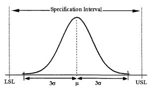

Intervalo de especificación vs. propagación del proceso para la distribución Normal

Donde:

- USL: límite de especificación superior
- LSL: límite de especificación inferior.
- $\sigma$: desviación estándar del proceso.

Se tiene que el numerador proporciona el rango en el que las mediciones del proceso son aceptables, mientras que el el denominador indica el rango en el que realmente varía el proceso.

Este índice fue diseñado para medir la magnitud de la variación general del proceso en relación con la tolerancia la fabricación, el cual es utilizado en procesos basandos en datos normales, independientes y en control estadístico.

Como $\sigma$ es un parámetro desconocido, se lo estima ya sea por $\textbf{s}$ que es el estimador de la desviación estándar para datos normales o por $\overline R / d^2$

Lo que se desearía es que los valores de $C_P$ sean lo más grande posible; pequeños valores (menores a 1) no son aceptables puesto que esto señala que el rango natural de variación del proceso no se ajusta y probablemente excede las badas de tolerancia.

### **Índice $C_{pk}$**

Debido a la simplicidad en su diseño, en índice $C_P$ no toma en cuenta donde se encuentra la media del proceso respecto a los límites de especificación, por lo tanto no da ninguna indicación del rendimiento real del proceso.

Con el fin de tener en cuenta las desviaciones de la media del proceso respecto al valor objetivo, se han propuesto varios índices parecidos al índice $C_P$. Estos índices intentan explicar la magnitud de la variación del proceso, así como las desviaciones del proceso del valor objetivo.

De esta manera se define el índice $C_{pk}$ como:
$$C_{pk}=mín\left[\frac{USL-\mu}{3\sigma},\frac{\mu-LSL}{3\sigma}\right]$$
Donde:

- $\mu$: media del proceso.
- USL: límite de especificación superior.
- LSL: límite de especificación inferior.
- $\sigma$: desviación estándar del proceso.

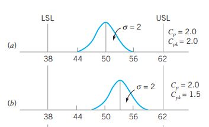

Comparación índices $C_p$ y $C_{pk}$

De forma general Si $C_P = C_{pk}$ el proceso esta centrado en el punto medio de las especifícaciones, mientras que si $C_P > C_{pk}$ el proceso no esta centrado.

### **Índice $C_{pm}$**

Tomando en cuenta que el índice $C_{pk}$ no es un buen índicador por si solo sobre el centrado del proceso, puesto que este debe ser comparado con el índice $C_p$, ya que como se observo antes si se cumple $C_P = C_{pk}$ entonces podemos decir que el proceso esta centrado. A diferencia del índice $C_p$ un valor alto para el índice $C_{pk}$ no nos dice nada sobre el centrado del proceso.

Para resolver este problema, se introduce el índice $C_{pm}$ por Hsiang y Taguchi en 1985, independiente del índice $C_p$. Este índice involucra la variación de los artículos de producción con respecto al valor objetivo y los límites de especificación.

Esta definido de la siguiente manera:
$$C_{pm}=\frac{USL-LSL}{6\sqrt{\sigma^2+(\mu-T)^2}}=\frac{USL-LSL}{6\tau}$$
Donde:

- USL: límite de especificación superior.
- LSL: límite de especificación inferior.
- $\tau$: es una medida de desviación promedio del producto con respecto al valor objetivo T.

Multiplicando y diviendo para $\sigma^2$ tenemos que:

$$C_{pm}=\frac{C_p}{6\sqrt{1+\xi^2}}, \space con \space \xi=\frac{\mu-T}{\sigma}$$
de esta manera resulta que una estimación para el índice $C_{pm}$ será:

$$\hat C_{pm}=\frac{\hat C_p}{\sqrt{1+V^2}}, \space con \space V=\frac{\overline x -T}{s}.$$
Boyles en 1991 proporciona un análisis sobre $C_{pm}$ y su utilidad para medir el centrado de los procesos. Señala que los índices $C_{pm}$,$C_{pk}$ y $C_P$ coinciden cuando $\mu =T$ y disminuye a medida que $\mu$ se aleja de T.

Boyles muestra que el $C_{pm}$ de un proceso con $|\mu-T|=\bigtriangleup>0$ esta estrictamente limitado por arriba por el valor $C_p$ de un proceso con $\sigma = \bigtriangleup$. Esto es,
$$C_{pm}<\frac{USL-LSL}{6|\mu-T|}$$
Por tanto para que $C_{pm}\geq 1$ una condición necesaria es que:

$$|\mu-T|<\frac{1}{6}(USL-LSL)$$
.

### **Índice $C_{pmk}$**

Este índice propuesto por Pearn en 1992 combina los méritos de los índices $C_{pm}$,$C_{pk}$ y $C_p$. $C_{pmk}$ alerta el usuario cuando la variación del proceso aumenta y la media del proceso se aleja del valor objetivo T. Este se define de la siguiente manera:

$$C_{pk}=mín\left[\frac{USL-\mu}{6\sqrt{\sigma^2+(\mu-T)^2}},\frac{\mu-LSL}{6\sqrt{\sigma^2+(\mu-T)^2}}\right]$$

## Índices de capacidad multivariados

En la mayoría de los procesos, los productos poseen múltiples características de calidad en lugar de una sola. Los procesos con características múltiples son ahora tan comunes, que los estudios sobre índices de capacidad no pueden restringirse al dominio univariante.

La relación multivariante entre las características de calidad puede o no reflejarse en las especificaciones. Por ejemplo, las USL y las LSL pueden darse por separado para cada característica de calidad.

En casos de dos dimensiones, estos rangos de tolerancia componen una región de tolerancia rectangular. En dimensiones superiores, forman un hipercubo. Para especificaciones más complejas, la región de tolerancia podría ser bastante complicada.

### **Índice $C_{pm}$**

Chan et al.(1991) introducen una versión multivariante del índice $C_{pm}$. Se consideran medidas de un conjunto de características de tamaño v $x_1,x_2,\dots, x_v$. Para la región de especificación todos los puntos que se encuentran dentro del límite de especificación satisfacen la desigualdad:
$$(\underline X -T)'A^{-1}(\underline X -T)\leq c^2$$

Donde:

- $\underline X = \left[ x_1,x_2,\dots, x_v\right]$
- $T= \left[ T_1,T_2,\dots, T_v\right]$
- $A$ es una matriz definida positiva de dimensiones vxv

A y T determinan completamente la forma y centro de la elipsoide, mientras que c determina la cobertura de la elipsoide. Hay que notar que la cobertura es el porcentaje de observaciones que se espera estén dentro de los límites.

De esta manera se define el índice $C_{pm}$ como:

$$C_{pm}= \sqrt{\frac{v}{E\left[(\underline X_i -T)'A^{-1}(\underline X_i -T)\right]}}$$

y su estimador como:

$$\hat C_{pm}= \sqrt{\frac{nv}{\sum_{i=1}^{n}(\underline X_i -T)'A^{-1}(\underline X_i -T)}}$$
Donde:

- $v$: es el número de variables usados para evaluar la capacidad del proceso.
- $\underline X_i:$ es el i-ésimo vector de dimensión v.
- $T$: es el valor objetivo.
- $A$: es la matriz que representa la estructura de covarianza determinada a partir de los límites de especificación.

Por tanto se tiene que para valores cerca del valor objetivo, el denomidaro se vuelve muy pequeño generando un valor de $\hat C_{pm}$ grande lo que índica que el proceso es capaz de cumplir las especificaciones; mientras para valores muy grandes en el denomiador harán que el valor de $\hat C_{pm}$ sea muy pequeño lo que nos índica que el proceso no es capaz de cumplir las especificaciones.

### **Índice $MC_{pm}$**

Taam et al.(1993) propusieron un índice de capacidad multivariante que se define como una proporción de dos volumenes:

$$MC_{pm}=\frac{Vol.(R_1)}{Vol.(R_2)}$$
Donde:

- $R_1$: región de tolerancia modificada
- $R_2: (\underline X - \mu)\Sigma_T^{-1}(\underline X - \mu) \leq K(q)$, es una región eliptica bajo la asumpción de normalidad.

La región de tolerancia modificada es la elipsoide más grande que esta centrada en el objetivo, completamente dentro de la tolerancia original.

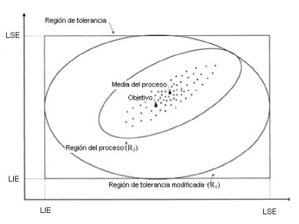

Región de tolerancia modificada

Cuando el proceso se encuentra en control estadístico la media del proceso se encuentra en control estadístico y la variación del proceso es pequeña respecto a las especificaciones de ingeniería. Por este lado el índice $MC_{pm}$ debería estar cerca de 1.

Una estimación esta dada por:

$$\widehat {MC_{pm}}=\frac{\hat C_{p}}{\hat D}$$
Aquí se tiene:
$$\hat C_{p} = \frac{Vol.(\text{Región de tolerancia})}{Vol.(\text{Región estimada del del proceso} )}$$
Teniendo en cuenta que:

$$Vol.(\text{Región estimada del proceso} ) = |S|^{\frac{1}{2}} (\pi K(v))^{\frac{1}{2}}\left[\Gamma(\frac{v}{2}+1)^{-1}\right]$$
y,

$$\hat D=\left[1+\frac{n}{n-1}(\underline {\overline X} -T)'S^{-1}(\underline {\overline X} -T)\right]^{\frac{1}{2}}$$

Dode:

- $S$: matriz de varianza-covarianza estimada
- $K(v)$: es el percentil 99,73% de la distribución chi-cuadrado con $v$ grados de libertad.

Se debe notar que $\hat C_p$ es análogo al índice univariante y el valor $\frac{1}{\hat D}$ nos índica para valores grandes que la media del proceso esta cerca del valor objetivo.

### **Índice $MC_p$**

Chen (1994) propone un índice basado en la zona de tolerancia, la cual es expresada como:

$$V=\left[X \in R^v: h(\underline X- \mu_0)\leq r_0\right]$$

- h(.): función homogénea no negativa que satisface $h(tx)=th(x)$ $\forall t$
- $r_0$: número positivo

el índice propuesto es:

$$MC_p=\frac{r_0}{r}$$
tomando en cuenta los siguientes puntos:

- El proceso se concidera capaz si $P(h(\underline X- \mu_0)\leq r_0)\geq 1-\alpha$, con $\alpha$ la proporción permitida de no conformidades en el proceso por lo general 0,27%.
- $r=min \left[c: h(\underline X- \mu_0)\leq c)\geq 1-\alpha \right]$.
- El proceso es capaz si $M_{cp}=\frac{r_0}{r}\geq 1$.
- Si $MC_{p}=1$ entonces la proporción de no conformidades es exactamente $\alpha$.
- No hay suposición sobre el tipo de distribución usada.

### **Índice de Capacidad Shariari**

Shariari et al.(1995) propone un índice que consta de tres componentes.

El primero de ellos es una comparación de dos áreas o volumenes:

$$C_{pM}= \left[\frac{\text{Vol. región de tolerancia}}{\text {Vol. región modificada del proceso}} \right]^\frac{1}{v}$$
Este enfoque produce una “región de proceso modificada” al dibujar el rectángulo más pequeño alrededor de la elipse. Las esquinas de la región del proceso modificada se definen como los límites inferiores y superiores del proceso ($LPL_i \space y \space UPL_i$ para i=1,,v) definidos como:

$$UPL_i=\mu_i+\sqrt{\frac{\chi_{v,\alpha}^2|\Sigma_i^{-1}|}{|\Sigma^{-1}|}}, i=1,\dots,v$$
$$LPL_i=\mu_i-\sqrt{\frac{\chi_{v,\alpha}^2|\Sigma_i^{-1}|}{|\Sigma^{-1}|}}, i=1,\dots,v$$

Donde:

- $\chi_{v,\alpha}^2$ : es el cuantil superior $\alpha$ de la distribución $\chi^2$ con v grados de libertad.
- $|\Sigma_{i}^{-1}|$: determinante de $\Sigma_{i}^{-1}$ que se obtiene que quitar la i-ésima fila y columna de $\Sigma^{-1}$

Así se define como:

$$C_{pM}=\left[ \frac{\prod_{i=1}^{v}(USL_i-LSL_i)}{\prod_{i=1}^{v}(UPL_i-LPL_i)}\right]^\frac{1}{v}$$

Un valor mayor a 1 indica que la región modificada del proceso es más pequeña la región de tolerancia y por tanto es aceptable.

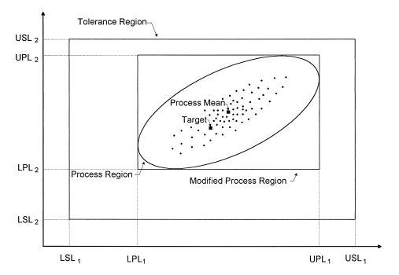

Región modificada del proceso

El segundo componente de este vector es el nivel de significancia del valor observado con el estadístico T^2 de Hotelling

$$T^2=n(\overline X-\mu_o)'S^{-1}(\overline X-\mu_o)$$
que se expresa como:

$$PV=P \left(T^2\geq {\frac{v(n-1)}{n-v}}F_{(v,n-v)}\right)$$
Donde:

- $F_{v,n-v}$ denota la distribución F con v,n-v grados de libertad.
- Como se define $T^2$ caber recalcar que es bajo la distribución normal.
- El valor PV no puede exceder 1. Para valores muy cercanos al cero el centro del proceso esta muy distante del valor objetivo de la región de tolerancia.

La tercera componente de este índice, toma solo dos valores, {0,1} y compara las localizaciones de la región del proceso modificada y la región de tolerancia.

Así, si toma el valor de 1 indica que la región modificada del proceso se encuentra totalmente contenida en la región de tolerancia y 0 en otro caso.

$$\begin{equation*}
LI =
\begin{cases}
1 & \text{si la región modificada del proceso esta contenida completamente en la región de tolerancia.}\\
0 & \text{caso contrario}
\end{cases}
\end{equation*}$$

Asi el índice está definido de la forma $\left[C_{pM}, PV, LI\right]$

### **Índices basados en PCA**

Wang and Du (2000) proponen un método muy útil basado en el análisis de componentes principales para describir el rendimiento del proceso para datos multivariantes. Hay que notar también que como regla los PCI’s multivariantes asumen una distribución normal de los datos, pero para aplicar PCA esto no es requerido.

Como ventajas podemos señalar:

- Transformar problemas de varias dimensiones en problemas con pocas dimensiones.
- Transformar datos correlacionados en datos independientes, que simplifica los cálculos en los PCI’s multivariantes.

Así se define la i-ésima componente principal como:

$$PC_{i}=u^Tx \space i=1,\dots,v$$
Así tenemos los límites de especificación y el valor objetivo como:
$$\begin{equation*}
\begin{cases}
LSL_{PC_i}=u_i^TLSL\\
USL_{PC_i}=u_i^TUSL & i=1,\dots,v\\
T_{PC_i}=u_iT
\end{cases}
\end{equation*}$$

De forma similar los estimadores $S$ y $\overline X$ están definidos de la forma:

$$S_{PC_i}=\lambda_i,$$

$${\overline {\underline {X}}}_{PC_i}=u_i^T{\overline {\underline {X}}}, \space i=1,\dots,v.$$

Donde se define:

- $\overline X:$ matriz de datos de dimension $(vxn)$.
- $\overline {\underline X}$: la media muestral de dimensión $(vx1)$.
- $S:$ matriz de varianza-covarianza de tamaño $(vxv)$.

Con el uso del teorema de descomposición espectral se obtiene la matriz $D=U^{T}SU$ con:

- $D:$ matriz diagonal con $\lambda_1,\dots,\lambda_v$ valores propios de $S$.
- $U:$ matriz donde sus columnas son $u_1,\dots,u_v$ son los vectores propios de $U$.

Se sabe que pocas componentes proncipales contribuyen a la mayor parte de la variabilidad total (entre el 70% y 90%).

De esta manera se tiene los índices para datos normales multivariantes y no multivariantes como:

#### **Datos normales multivariantes**

Se define:

$$\widehat{MC}_{p} =(\prod_{i=1}^v\hat{C}_{p;PC_i})^{1/v}$$
y,

$$\widehat{MC}_{pk} =(\prod_{i=1}^v\hat{C}_{pk;PC_i})^{1/v}$$
donde:

$$\hat{C}_{P;PC_i}=\frac{USL_{PC_i}-LSL_{PC_i}}{6\sqrt{S^2_{PC_i}}}$$
y,

$$\hat{C}_{pk;PC_i}=\frac{min\left \{{USL_{PCi}-\overline X_{PC_i}, \overline X_{PC_i}-LSL_{PCi}}\right \}}{3\sqrt{S^2_{PC_i}}}$$

#### **Datos normales no multivariantes**

Como se mencionó anteriormente, Luceño (1996) propuso un índice de capacidad de proceso, $C_{pc}$, diseñado para tener en cuenta tanto la ubicación del proceso como su extensión, así como para proporcionar límites de confianza que son insensibles a las desviaciones de los datos normales. Wang y Du (2000) proponen que para este tipo de datos la capacidad del proceso puede estimarse por:

$$\widehat{MC}_{pc} =\left(\prod_{i=1}^v\hat{C}_{pc;PC_i}\right)^{1/v}$$
donde:

$$\hat{C}_{pc;PC_i}=\frac{\left(USL_{PC_i}-LSL_{PC_i}\right)}{6\sqrt{\frac{\pi}{2 \overline c}}}$$

# Gráficos de Control r, Q, S

## ¿Qué es un gráfico de control?